# HW4_koopmann

Michael Koopmann

2/23/2022

Question Set 1:

```r
choco <- read.csv("https://ds202-at-isu.github.io/labs/data/choco.csv")
head(choco)
```

```
##    Company Specific.Bean.Origin  REF Review.Date Cocoa.Pct Company.Location
## 1 A. Morin          Agua Grande 1876        2016        63           France
## 2 A. Morin                Kpime 1676        2015        70           France
## 3 A. Morin               Panama 1011        2013        70           France
## 4 A. Morin           Madagascar 1011        2013        70           France
## 5 A. Morin               Brazil 1011        2013        70           France
## 6 A. Morin             Equateur 1011        2013        70           France
##   Rating Bean.Type Broad.Bean.Origin
## 1   3.75                    Sao Tome
## 2   2.75                        Togo
## 3   2.75                      Panama
## 4   3.00   Criollo        Madagascar
## 5   3.25                      Brazil
## 6   3.75                     Ecuador
```

```r
summary(choco$Rating)
```

```
##    Min. 1st Qu.  Median    Mean 3rd Qu.    Max.
##   1.000   3.000   3.250   3.191   3.500   5.000
```

1. There are 1852 chocolate bars rated with the Mean rating of 3.191
2. Plot of number of reports by year

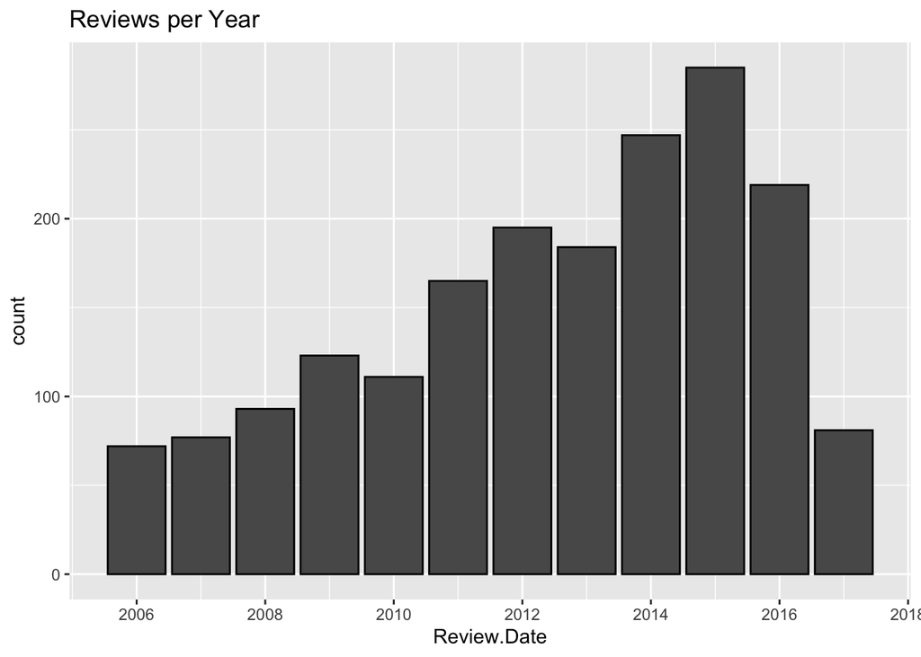

Question Set 2:

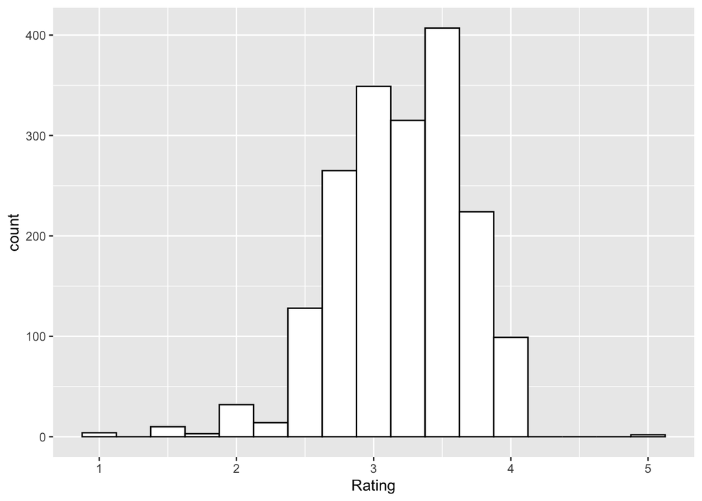

```r
ggplot(choco, aes(x = Rating)) + geom_histogram(bins = 17, colour="black", fill="white")
```

The graph shows high concentration of ratings between 2.5 and 4 and the sharp drop off after 4 and the few 5 ratings. Our Q1 is at 3 and Q3 is 3.5 so the range is .5 so all the ratings below 2.25 are outliers along with the marking at 5.

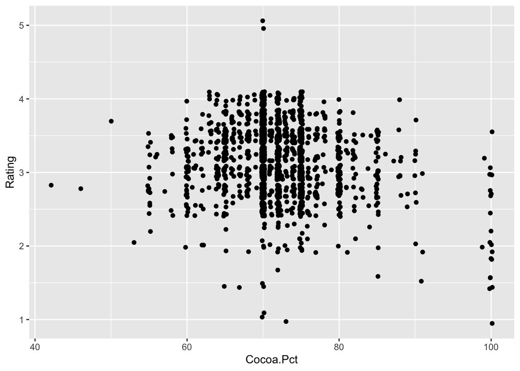

```r
ggplot(choco, aes(x = Cocoa.Pct, y = Rating)) + geom_jitter()
```

No I don’t see any trend within the plot theres lower percentage with the same rating as higher percentage. I will say that ideal range seems to be between 60 and 80 percentage.

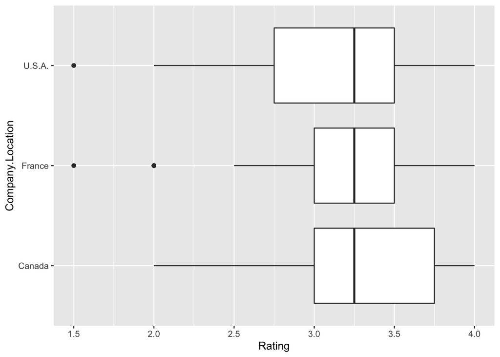

```r
subchoco <- dplyr::filter(choco, Company.Location %in% c("U.S.A.", "France", "Canada"))
ggplot(subchoco, aes(x = Company.Location, y = Rating))+
  geom_boxplot()+
  coord_flip()+
  ylab("Rating")
```

All 3 locations have a similiar mean but Canada has a larger upper quantile about double of France and USA which have similiar upper quantile. Also USA has a larger lower quantile which is about double France and Canada which have similiar lower quantile. All 3 upper adjacent goes to 4 but the lower adjacent of France only goes to 2.5 while Cananda and USA goes to 2. From this I’d say that France has better consistency of having a higher rating but Canada upper quantile being larger makes me say that they have the best ratings.